# Willamette Falls Fish Passage Time Series: A Summary

## SeasonPlots

**Steelhead**

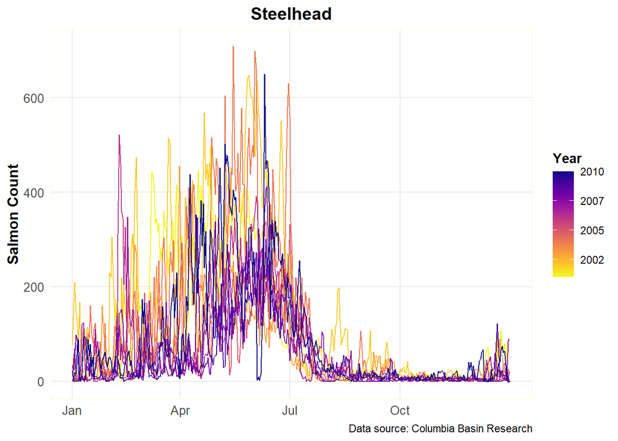

**Figure 3**. Steelhead Seasonality from 2001-2010 at Wllamette fish passage.

```r
# Enhanced steelhead plot
 salmon_daily %>%
  filter(fish_type == 'steelhead') %>%
  gg_season(daily_count, pal = rev(viridis::plasma(n = 10))) +
  theme_minimal() +
  theme(
    plot.title = element_text(face = "bold", size = 14, hjust = 0.5),
    plot.subtitle = element_text(size = 11, hjust = 0.5),
    axis.title = element_text(face = "bold", size = 12),
    axis.text = element_text(size = 10),
    legend.title = element_text(face = "bold"),
    legend.position = "right",
    panel.grid.minor = element_blank(),
    panel.border = element_rect(color = "cornsilk", fill = NA)) +
  labs(
    x = NULL,
     y = "Salmon Count",
    title = "Steelhead",
    color = "Year",
    caption = "Data source: Columbia Basin Research")
```

**Jack Coho**

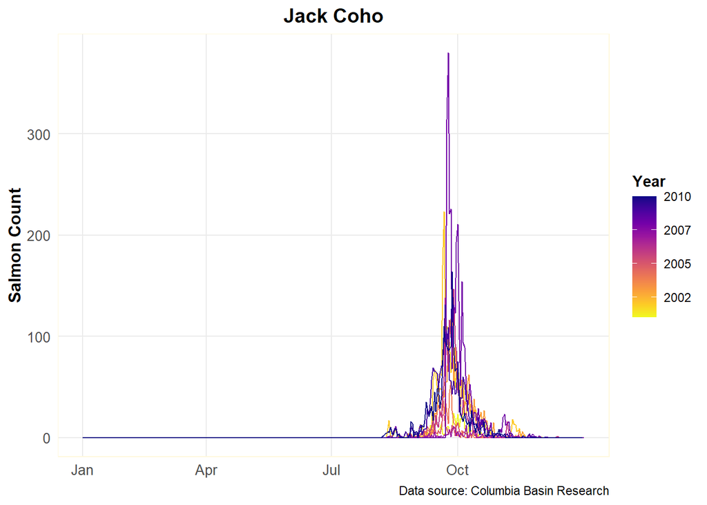

**Figure 4**. Jack Coho Seasonality from 2001-2010 at Wllamette fish passage.

```r
#jack coho plot
salmon_daily %>%
  filter(fish_type == 'jack_coho') %>%
  gg_season(daily_count,  pal = rev(viridis::plasma(n = 10)))  +
  theme_minimal() +
  theme(
    plot.title = element_text(face = "bold", size = 14, hjust = 0.5),
    plot.subtitle = element_text(size = 11, hjust = 0.5),
    axis.title = element_text(face = "bold", size = 12),
    axis.text = element_text(size = 10),
    legend.title = element_text(face = "bold"),
    legend.position = "right",
    panel.grid.minor = element_blank(),
    panel.border = element_rect(color = "cornsilk", fill = NA)) +
  labs(
    x = NULL,
     y = "Salmon Count",
    title = "Jack Coho",
    color = "Year",
    caption = "Data source: Columbia Basin Research")
```

**Coho**

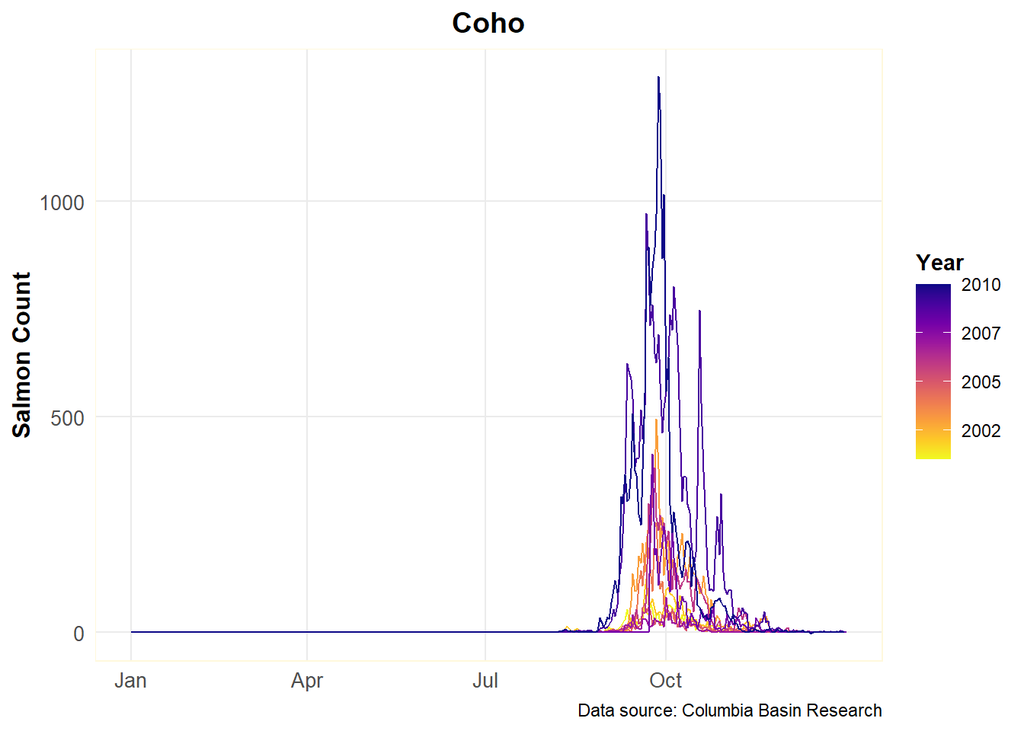

**Figure 5**. Coho Seasonality from 2001-2010 at Wllamette fish passage.

```r
#coho plot
salmon_daily %>%
  filter(fish_type == 'coho') %>%
  gg_season(daily_count, pal = rev(viridis::plasma(n = 10))) +
  theme_minimal() +
  theme(
    plot.title = element_text(face = "bold", size = 14, hjust = 0.5),
    plot.subtitle = element_text(size = 11, hjust = 0.5),
    axis.title = element_text(face = "bold", size = 12),
    axis.text = element_text(size = 10),
    legend.title = element_text(face = "bold"),
    legend.position = "right",
    panel.grid.minor = element_blank(),
    panel.border = element_rect(color = "cornsilk", fill = NA)) +
  labs(
    x = NULL,
    y = "Salmon Count",
    title = "Coho",
    color = "Year",
    caption = "Data source: Columbia Basin Research")
```

**Notable Trends**

### Seasonplot for Three Salmon Species

- By overlaying each years data signified with a different color onto a single plot, it becomes easier to assess the seasonality for each species.
- Both Coho and Jack Coho have a similar seasonal pattern, with a tight clustering around the peak in October.
- Steelhead, on the other hand, have a peak over the summer. The seasonality is not as clearly defined as with the other two, showing peaks in multiple months across the time series.